# Different languages, similar encoding efficiency

Full statistical analysis and plots

Christophe Coupé, Yoon Mi Oh, Dan Dediu and François Pellegrino

Sat Jun 22 22:38:35 2019

## Introduction

This `Rmarkdown` script (and the corresponding TAB-separated CSV input data files `InfoRateData.csv` and `AutomaticSylDetect.csv`, and the resulting `HTML` document) contains the full analysis and plotting code accompanying the paper *Different languages, similar encoding efficiency: comparable information rates across the human communicative niche*.

## The data

For more information on the data, please see Oh (2015). There are in total 17 languages (see the table below).

### The Oral Corpus

The oral corpus is based on a subset of the *Multext* (Multilingual Text Tools and Corpora) parallel corpus (Campione & Véronis, 1998) in *British English*, *German*, and *Italian*. The material consists of 15 short texts of 3-5 semantically connected sentences carefully translated by a native speaker in each language.

For the other 14 languages, two of the authors supervised the translation and recording of new datasets. All participants were native speakers of the target language, with a focus on a specific variety of the language when possible – e.g. *Mandarin* spoken in Beijing, *Serbian* in Belgrade and *Korean* in Seoul. No strict control on age or on the speakers’ social diversity was performed, but speakers were mainly students or members of academic institutions. Speakers were asked to read three or four times (first silently and then loudly two or three times) each text. The texts were presented one by one on the screen in random order, in a self-paced reading paradigm. This way, speakers familiarized themselves with the text and reduced their reading errors. The last loud recording was analyzed in this study.

With these, the oral corpus contains 2288 texts read by 170 speakers coming from 17 languages and 15 texts.

For each language and text we have the following number of syllables (*NS*):

Number of syllables (*NS*) per language and text.

| Language | Text | NS |
| --- | --- | --- |
| CAT | O1 | 88 |
| CAT | O2 | 118 |
| CAT | O3 | 139 |
| CAT | O4 | 142 |
| CAT | O6 | 99 |
| CAT | O8 | 131 |
| CAT | O9 | 81 |
| CAT | P0 | 122 |
| CAT | P1 | 127 |
| CAT | P2 | 118 |
| CAT | P3 | 131 |
| CAT | P8 | 117 |
| CAT | P9 | 119 |
| CAT | Q0 | 127 |
| CAT | Q1 | 93 |
| CMN | O1 | 60 |
| CMN | O2 | 73 |
| CMN | O3 | 73 |
| CMN | O4 | 80 |
| CMN | O6 | 64 |
| CMN | O8 | 69 |
| CMN | O9 | 57 |
| CMN | P0 | 100 |
| CMN | P1 | 70 |
| CMN | P2 | 65 |
| CMN | P3 | 77 |
| CMN | P8 | 78 |
| CMN | P9 | 76 |
| CMN | Q0 | 68 |
| CMN | Q1 | 57 |

[output cut: 225 more lines]

### Text Corpus

Text datasets were acquired from various sources as illustrated in the table below. After an initial data curation, each dataset was phonetically transcribed and automatically syllabiﬁed by a rule-based program written by one of the authors, except in the following cases:

1. when syllabiﬁcation was already provided with the dataset (*English*, *French*, *German*, and *Vietnamese* for the multisyllabic words);
2. when the corpus was syllabiﬁed by an automatic grapheme-to-phoneme converter (*Catalan*, *Spanish*, and *Thai*).

Additionally, no syllabiﬁcation was required for Sino-Tibetan languages (*Cantonese* and *Mandarin Chinese*) since one ideogram corresponds to one syllable.

| Language | Family | ISO 639-3 | Corpus |
| --- | --- | --- | --- |
| Basque | Basque | EUS | E-Hitz (Perea et al., 2006) |
| British English | Indo-European | ENG | WebCelex (MPI for Psycholinguistics) |
| Cantonese | Sino-Tibetan | YUE | A linguistic corpus of mid-20th century Hong Kong Cantonese |
| Catalan | Indo-European | CAT | Frequency dictionary (Zséder et al., 2012) |
| Finnish | Uralic | FIN | Finnish Parole Corpus |
| French | Indo-European | FRA | Lexique 3.80 (New et al., 2001) |
| German | Indo-European | DEU | WebCelex (MPI for Psycholinguistics) |
| Hungarian | Uralic | HUN | Hungarian National Corpus (Váradi, 2002) |
| Italian | Indo-European | ITA | The PAISÀ Corpus (Lyding et al., 2014) |
| Japanese | Japanese | JPN | Japanese Internet Corpus (Sharoff, 2006) |
| Korean | Korean | KOR | Leipzig Corpora Collection (LCC) |
| Mandarin Chinese | Sino-Tibetan | CMN | Chinese Internet Corpus (Sharoff, 2006) |
| Serbian | Indo-European | SRP | Frequency dictionary (Zséder et al., 2012) |
| Spanish | Indo-European | SPA | Frequency dictionary (Zséder et al., 2012) |
| Thai | Tai-Kadai | THA | Thai National Corpus (TNC) |
| Turkish | Turkic | TUR | Leipzig Corpora Collection (LCC) |
| Vietnamese | Austroasiatic | VIE | VNSpeechCorpus (Le et al., 2004) |

### Dataset structure

The data is structured as follows:

- *Language* is the unique language ISO 639-3 ID with 17 possible values: “CAT”, “CMN”, “DEU”, “ENG”, “EUS”, “FIN”, “FRA”, “HUN”, “ITA”, “JPN”, “KOR”, “SPA”, “SRP”, “THA”, “TUR”, “VIE”, “YUE”;
- *Language family* is the language family with 9 possible values: “Austroasiatic”, “Basque”, “Indo-European”, “Japanese”, “Korean”, “Sino-Tibetan”, “Tai-Kadai”, “Turkic”, “Uralic”;
- *Text* is the text identifier (similar across languages and speakers) with 15 possible values: “O1”, “O2”, “O3”, “O4”, “O6”, “O8”, “O9”, “P0”, “P1”, “P2”, “P3”, “P8”, “P9”, “Q0”, “Q1”;
- *Speaker* is the unique speaker’s ID (there are 170 in the dataset);
- *Sex* is the speaker’s sex;
- *Age* is the speaker’s age (available only for a subset of 132 speakers);
- *Duration* is the duration of the texts in seconds as spoken by a given speaker (pauses longer than 150ms being excluded);
- *NS* is the number of of syllables of the texts (the same for a given text in a given language);
- *SR* is the speech rate (syllables/second) for a given text spoken by a given speaker;
- *ShE* (resp. *ID*) is the first-order (resp. second-order) language-level entropy estimate;
- *ShIR* and *IR* are text * speaker properties obtained by multiplying *SR* by *ShE* and *ID* respectively.

### Technical notes on regressions

We use throughout *sum contrasts* for the factor IVs, which are orthogonal contrasts which compare every level of the IV to the overall mean (for example, for a two-levels factor such as *Sex* we do not compare *Males* with *Females* but each with their overall mean, which is included in the intercept). However, in `R` the `contr.sum()` function used to define these contrasts produces level names that are very uninformative, so we explicit these below (please note that in the model outputs the *last* level is usually not shown):

- *Sex*: `Sex1` = *F*, `Sex2` = *M* (the last level, `Sex2,` is usually not displayed);
- *Text*: `Text1` = *O1*, `Text2` = *O2*, `Text3` = *O3*, `Text4` = *O4*, `Text5` = *O6*, `Text6` = *O8*, `Text7` = *O9*, `Text8` = *P0*, `Text9` = *P1*, `Text10` = *P2*, `Text11` = *P3*, `Text12` = *P8*, `Text13` = *P9*, `Text14` = *Q0*, `Text15` = *Q1* (the last level, `Text15,` is usually not displayed);
- *Language*: `Language1` = *CAT*, `Language2` = *CMN*, `Language3` = *DEU*, `Language4` = *ENG*, `Language5` = *EUS*, `Language6` = *FIN*, `Language7` = *FRA*, `Language8` = *HUN*, `Language9` = *ITA*, `Language10` = *JPN*, `Language11` = *KOR*, `Language12` = *SPA*, `Language13` = *SRP*, `Language14` = *THA*, `Language15` = *TUR*, `Language16` = *VIE*, `Language17` = *YUE* (the last level, `Language17,` is usually not displayed);
- *Family*: `Family1` = *Austroasiatic*, `Family2` = *Basque*, `Family3` = *Indo-European*, `Family4` = *Japanese*, `Family5` = *Korean*, `Family6` = *Sino-Tibetan*, `Family7` = *Tai-Kadai*, `Family8` = *Turkic*, `Family9` = *Uralic* (the last level, `Family9,` is usually not displayed);

### Exploratory plots and summaries

#### Speaker characteristics

Distribution of speaker number and characteristics (sex and age) by language. *Lng*=language, *# spkrs*=number of speakers, *% fem*=percentage of female speakers, *# age*=number of speakers with age info, and for those, *mean(age)*=mean age, *sd(age)*=standard deviation of age, and *actual ages*=the sorted ages.

| Lng | # spkrs | % fem | # age | mean(age) | sd(age) | actual ages |
| --- | --- | --- | --- | --- | --- | --- |
| CAT | 10 | 50 | 10 | 35.4 | 9.2 | (21, 28, 28, 29, 31, 39, 42, 42, 44, 50) |
| CMN | 10 | 50 | 9 | 23.1 | 4.5 | (19, 19, 19, 19, 24, 24, 25, 28, 31) |
| DEU | 10 | 50 | 0 | NaN | NaN | () |
| ENG | 10 | 50 | 0 | NaN | NaN | () |
| EUS | 10 | 50 | 10 | 28.0 | 4.9 | (19, 22, 26, 27, 28, 29, 30, 31, 32, 36) |
| FIN | 10 | 50 | 10 | 33.2 | 11.0 | (16, 22, 26, 28, 30, 35, 37, 41, 45, 52) |
| FRA | 10 | 50 | 10 | 32.5 | 7.7 | (24, 25, 25, 27, 28, 36, 36, 37, 41, 46) |
| HUN | 10 | 50 | 10 | 39.3 | 15.8 | (17, 27, 27, 31, 33, 39, 42, 51, 57, 69) |
| ITA | 10 | 50 | 0 | NaN | NaN | () |
| JPN | 10 | 50 | 10 | 30.6 | 12.8 | (20, 20, 21, 22, 22, 28, 29, 40, 51, 53) |
| KOR | 10 | 50 | 10 | 28.6 | 10.6 | (16, 19, 19, 19, 28, 31, 33, 35, 36, 50) |
| SPA | 10 | 50 | 10 | 33.7 | 10.1 | (21, 22, 26, 28, 30, 32, 42, 42, 44, 50) |
| SRP | 10 | 50 | 10 | 30.6 | 7.8 | (19, 21, 23, 30, 31, 32, 34, 34, 38, 44) |
| THA | 10 | 50 | 10 | 30.1 | 5.7 | (23, 23, 27, 28, 30, 31, 31, 32, 33, 43) |
| TUR | 10 | 50 | 7 | 32.6 | 7.2 | (24, 25, 30, 31, 37, 37, 44) |
| VIE | 10 | 50 | 6 | 27.2 | 4.1 | (21, 25, 26, 28, 31, 32) |
| YUE | 10 | 50 | 10 | 22.0 | 1.5 | (20, 20, 21, 21, 22, 22, 23, 23, 24, 24) |

#### NS

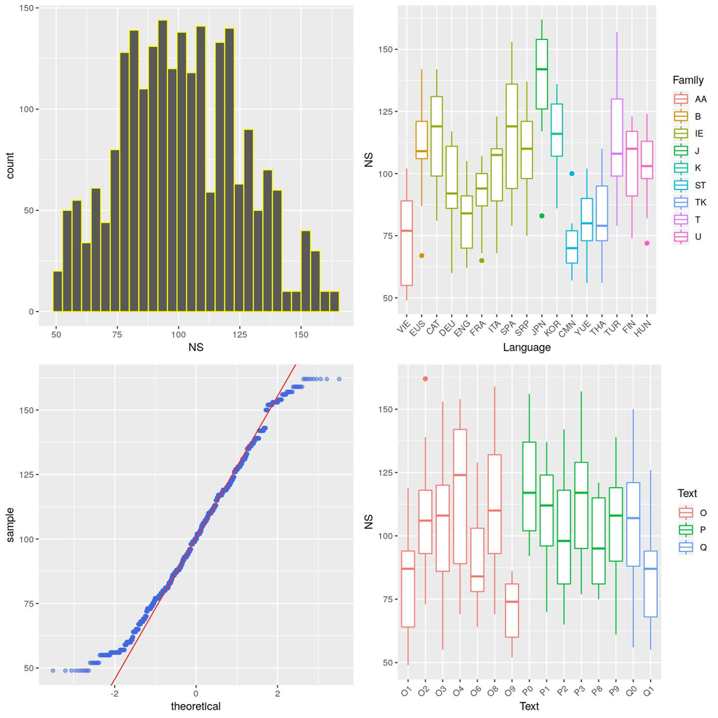

NS: exploratory plots.

```
mean=101.196, median=100, sd=24.703, CV=0.244, min=49, max=162, kurtosis=2.484, skewness=0.177.
```

#### SR

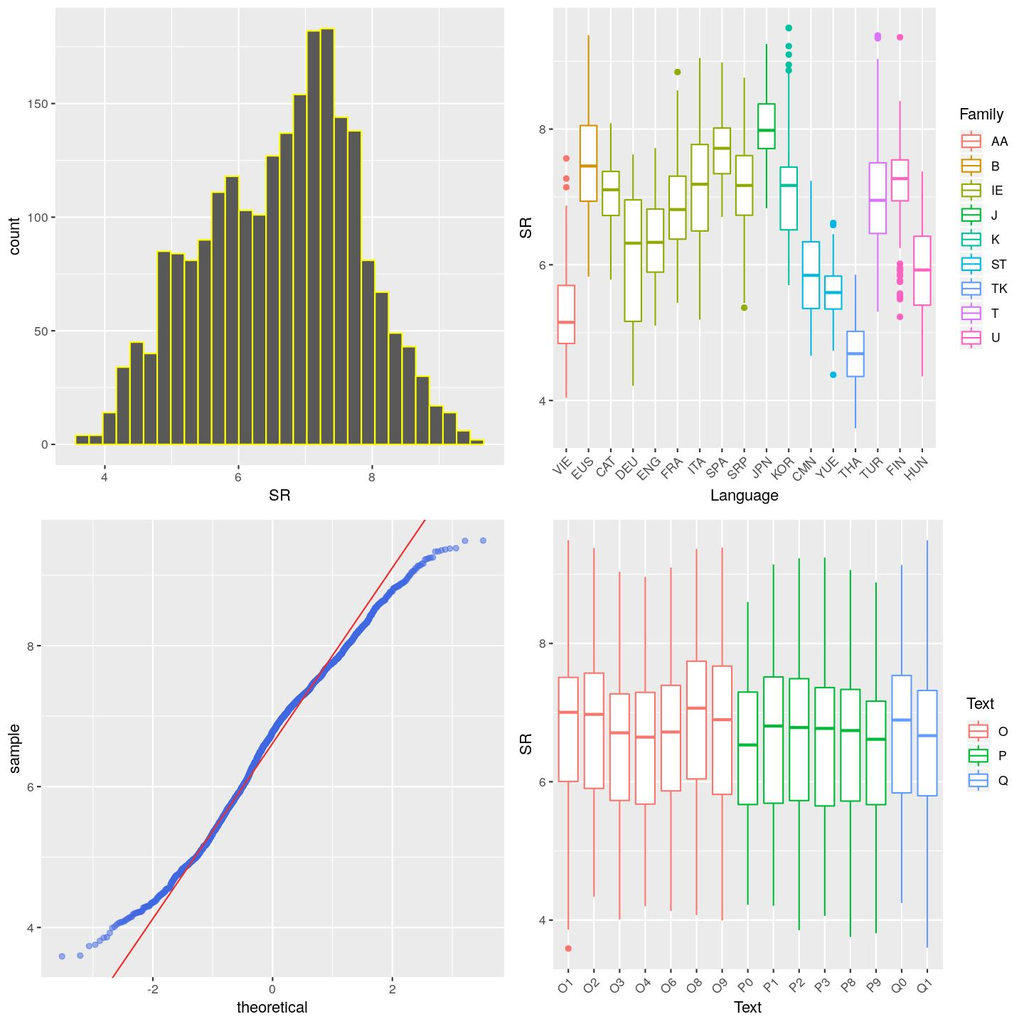

SR: exploratory plots.

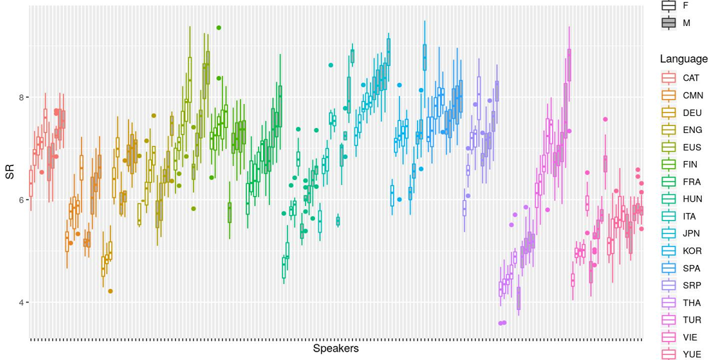

SR per speaker.

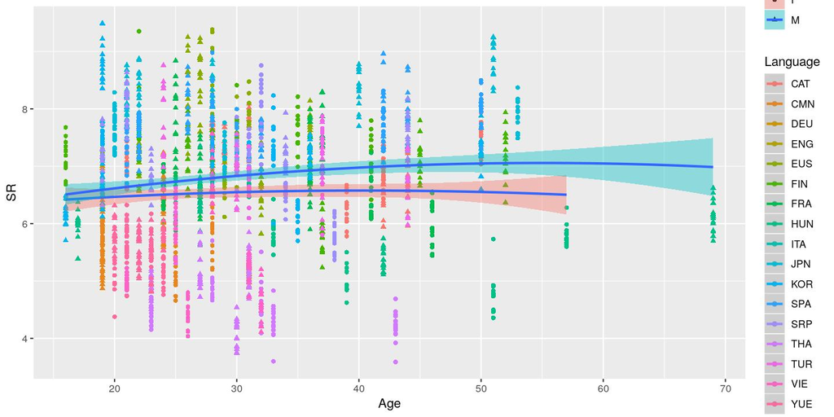

SR by Sex and Age across Languages.

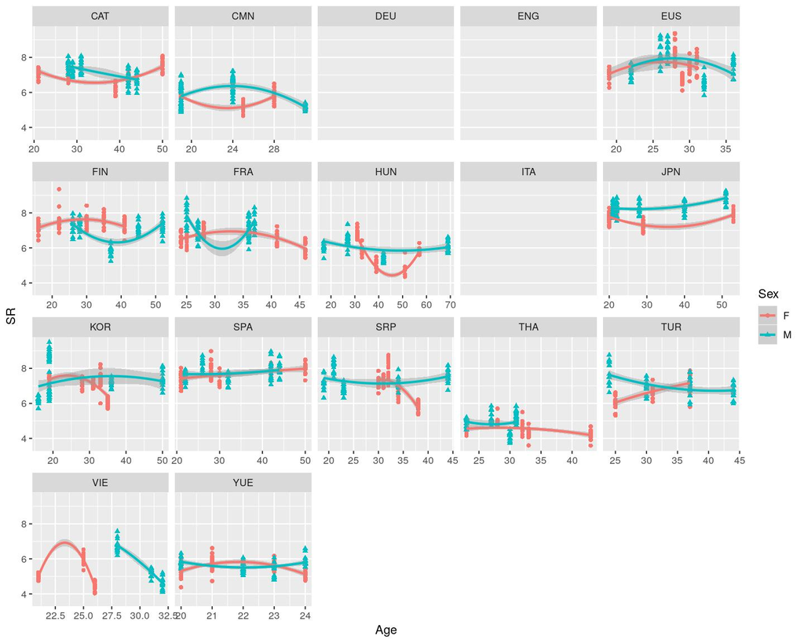

SR by Sex, Age and Language.

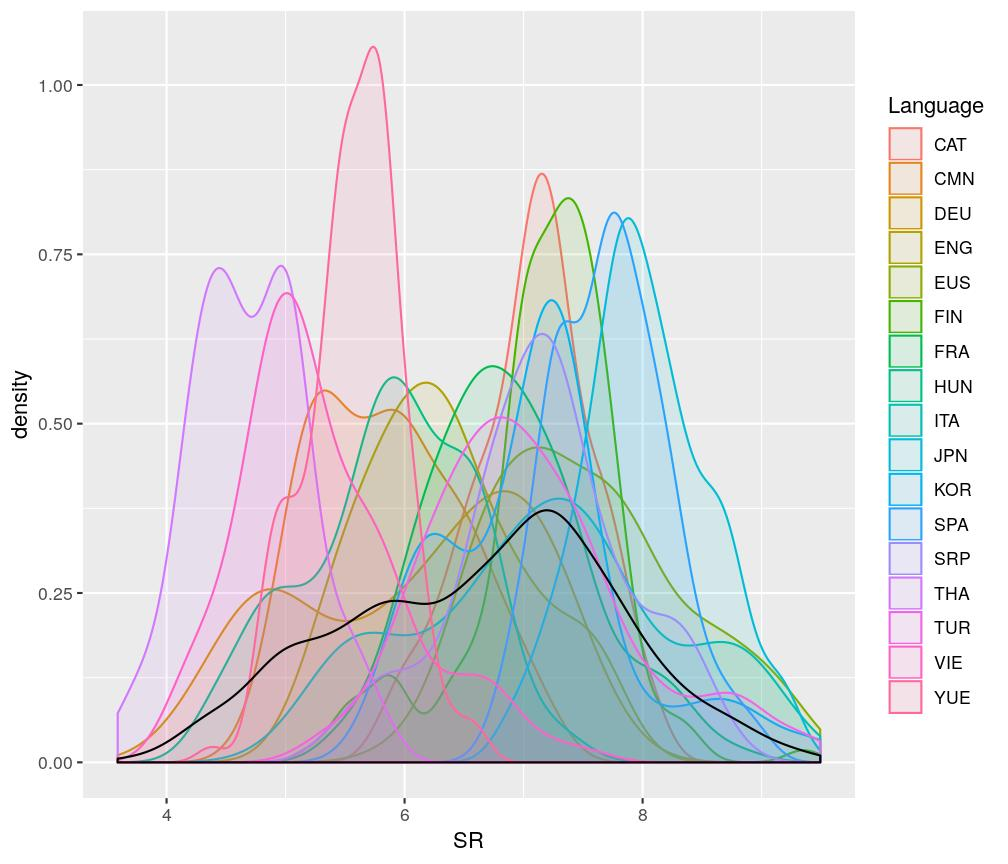

SR by language.

```
mean=6.631, median=6.777, sd=1.148, CV=0.173, min=3.589, max=9.492, kurtosis=2.408, skewness=-0.168.
```

#### ShE and ID

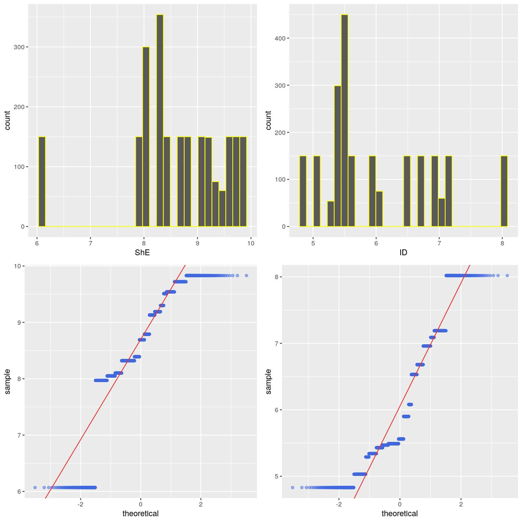

ShE and ID: exploratory plots.

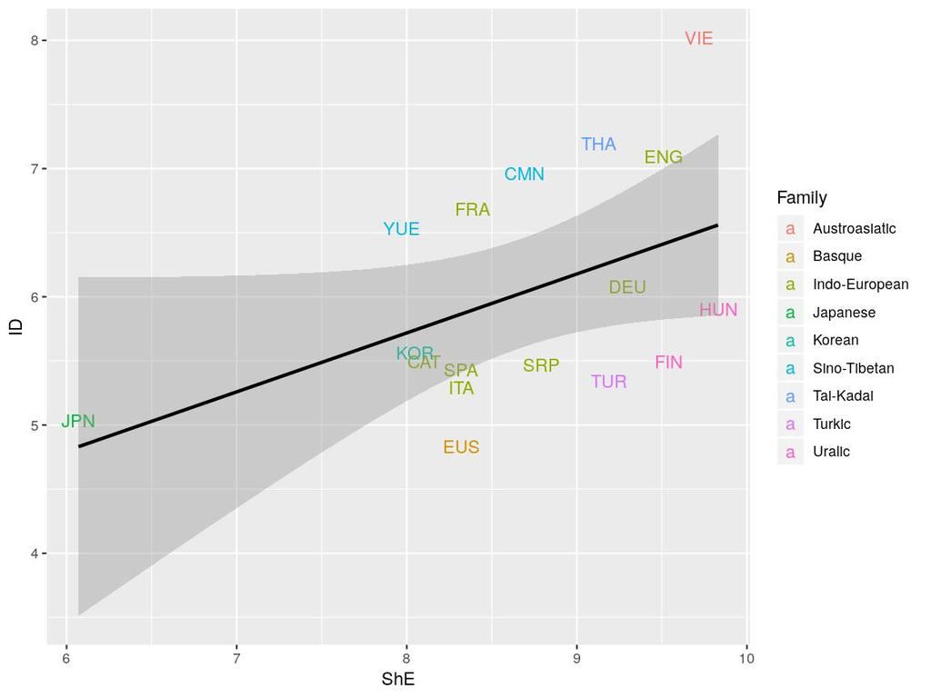

ShE vs ID.

```
    Pearson's product-moment correlation

data:  tmp1$ShE and tmp1$ID
t = 2.0326, df = 15, p-value = 0.06019
alternative hypothesis: true correlation is not equal to 0
95 percent confidence interval:
 -0.02052914  0.77274779
sample estimates:
      cor
0.4647009
```

```
    Spearman's rank correlation rho

data:  tmp1$ShE and tmp1$ID
S = 451.88, p-value = 0.07259
alternative hypothesis: true rho is not equal to 0
sample estimates:
      rho
0.4462208
```

```
    Paired t-test

data:  tmp1$ShE and tmp1$ID
t = 11.635, df = 16, p-value = 3.213e-09
alternative hypothesis: true difference in means is not equal to 0
95 percent confidence interval:
 2.158040 3.119607
sample estimates:
mean of the differences
               2.638824
```

*ShE:*

```
mean=8.621, median=8.69, sd=0.904, CV=0.105, min=6.07, max=9.83, kurtosis=4.665, skewness=-1.122.
```

*ID:*

```
mean=6.009, median=5.56, sd=0.883, CV=0.147, min=4.83, max=8.02, kurtosis=2.53, skewness=0.747.
```

#### ShIR and IR

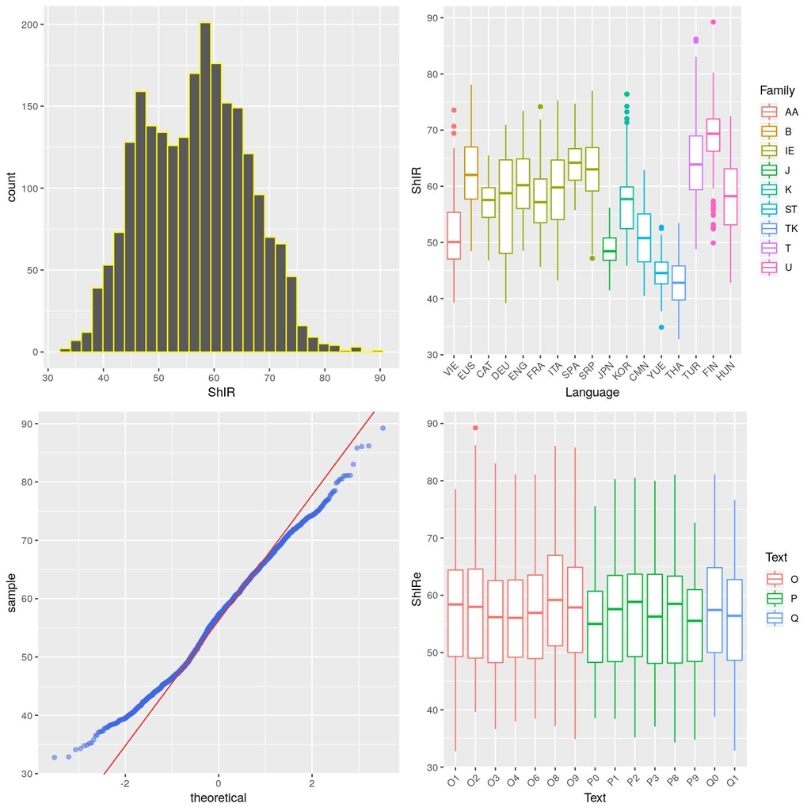

ShIR: exploratory plots.

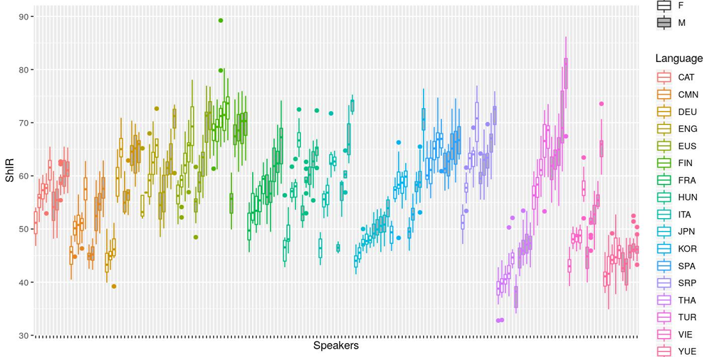

ShIR per speaker.

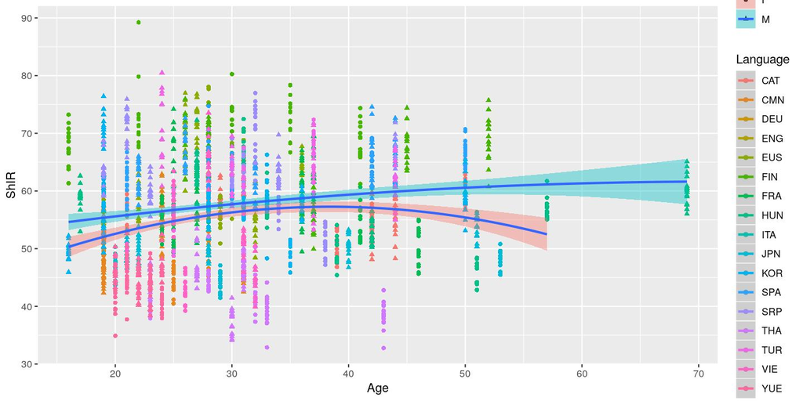

ShIR by Sex and Age across Languages.

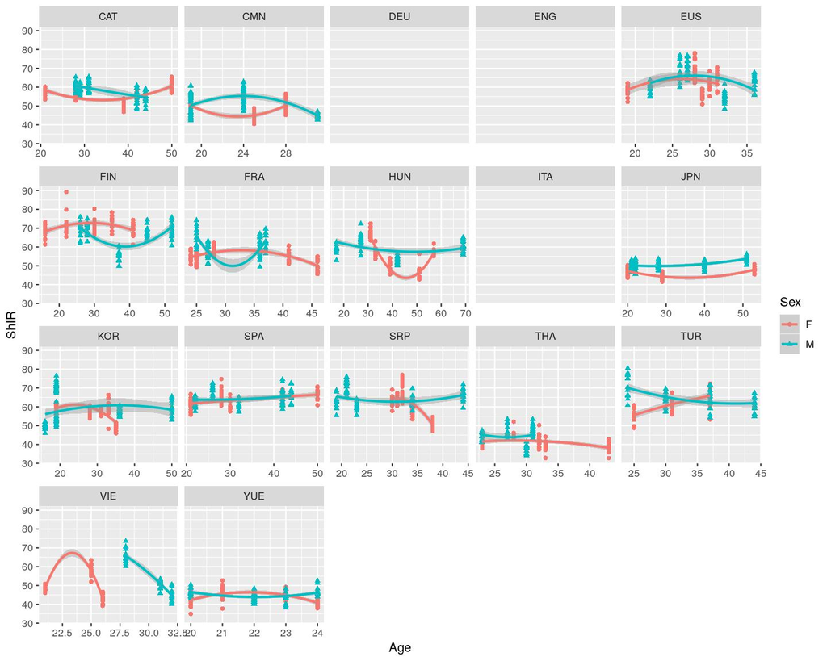

ShIR by Sex, Age and Language.

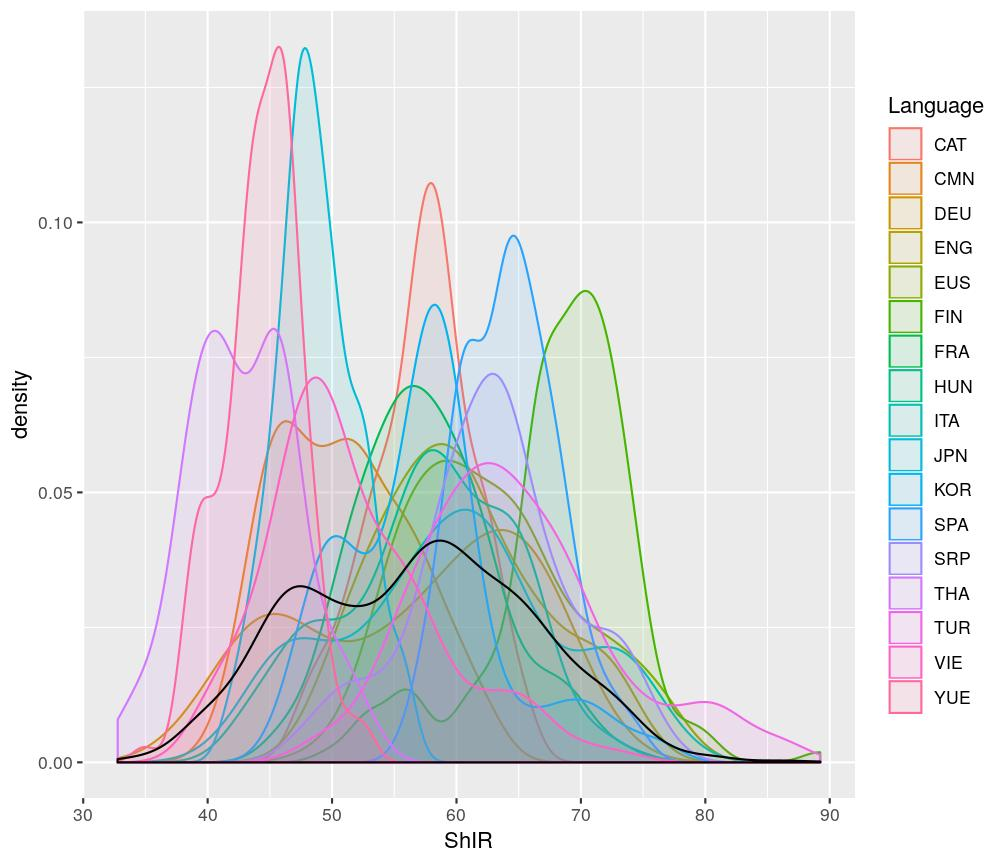

ShIR by language.

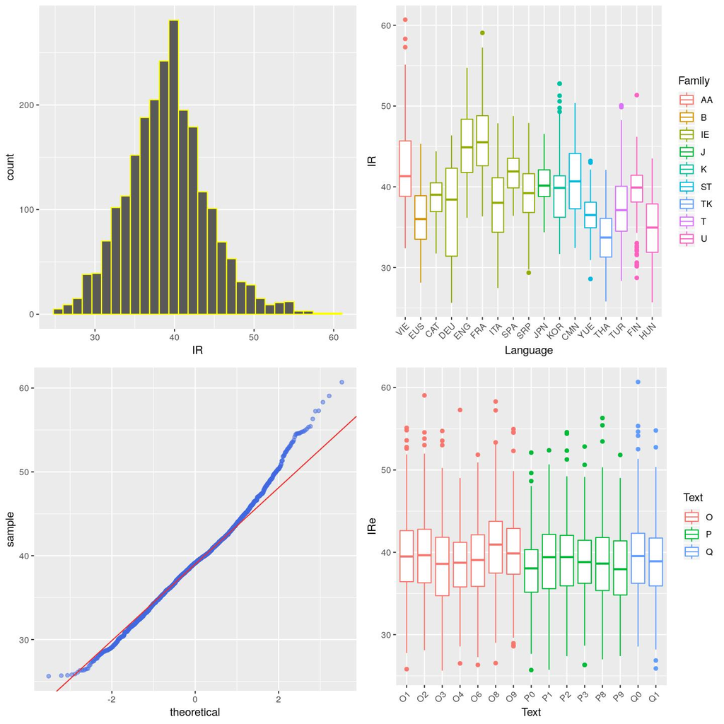

IR: exploratory plots.

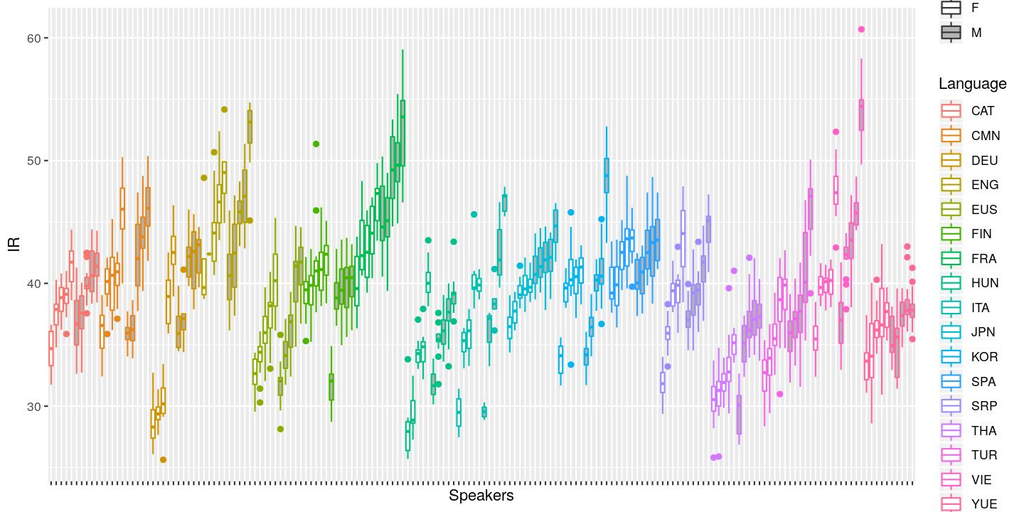

IR per speaker.

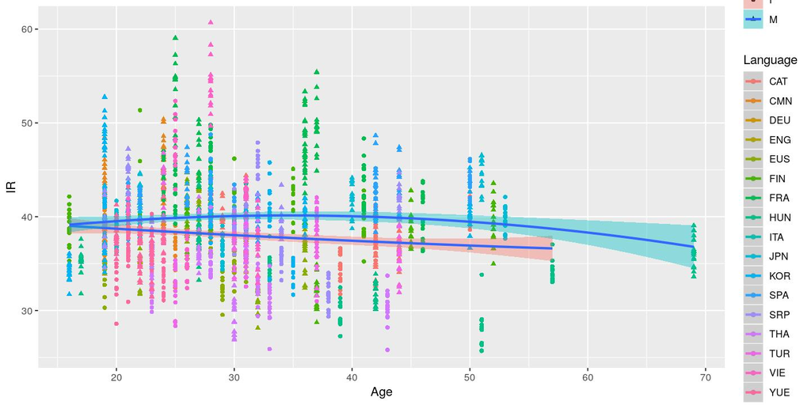

IR by Sex and Age across Languages.

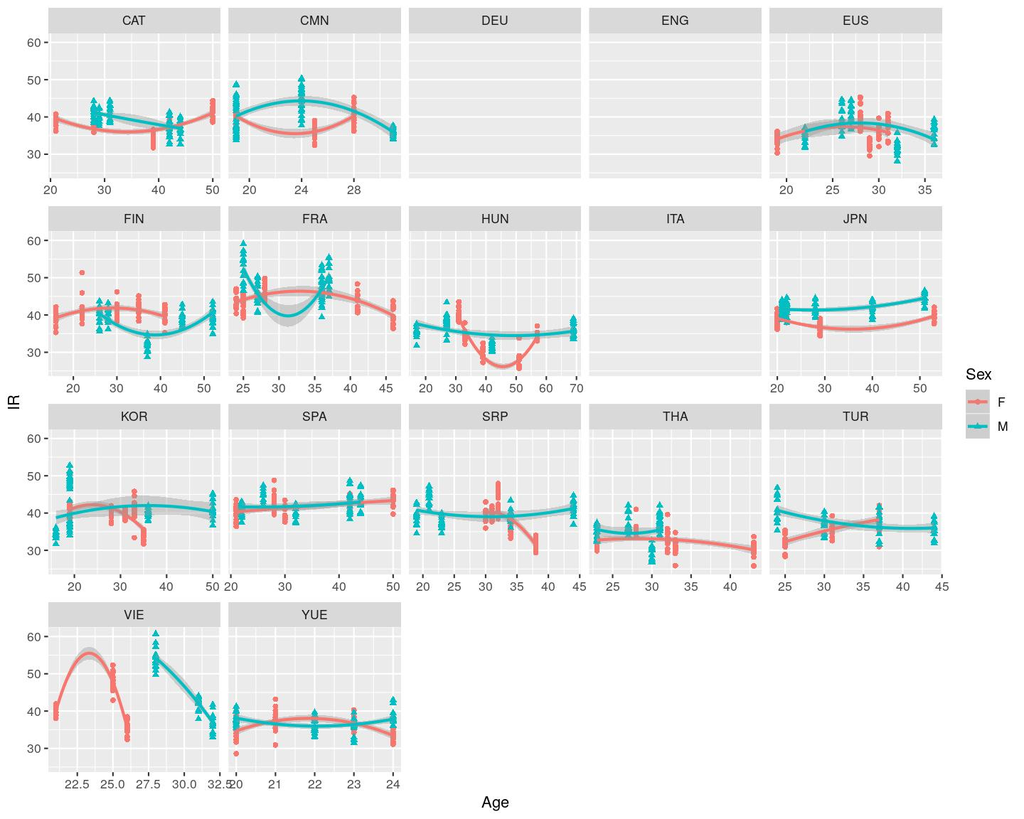

IR by Sex, Age and Language.

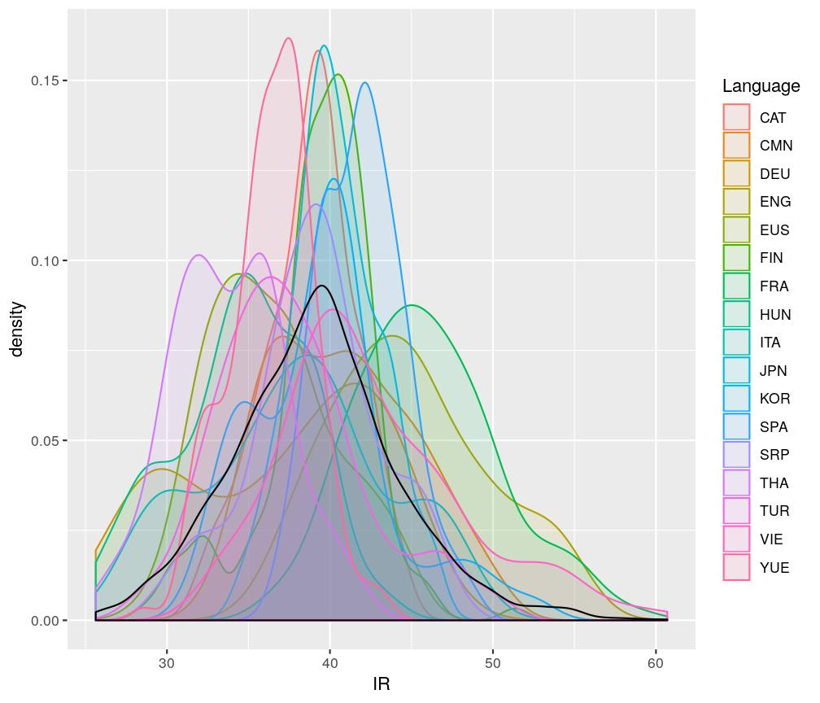

IR by language.

*ShIR:*

```
mean=56.709, median=57.207, sd=9.35, CV=0.165, min=32.772, max=89.235, kurtosis=2.444, skewness=0.079.
```

*IR:*

```
mean=39.153, median=39.13, sd=5.097, CV=0.13, min=25.631, max=60.692, kurtosis=3.622, skewness=0.325.
```

#### SR and ID

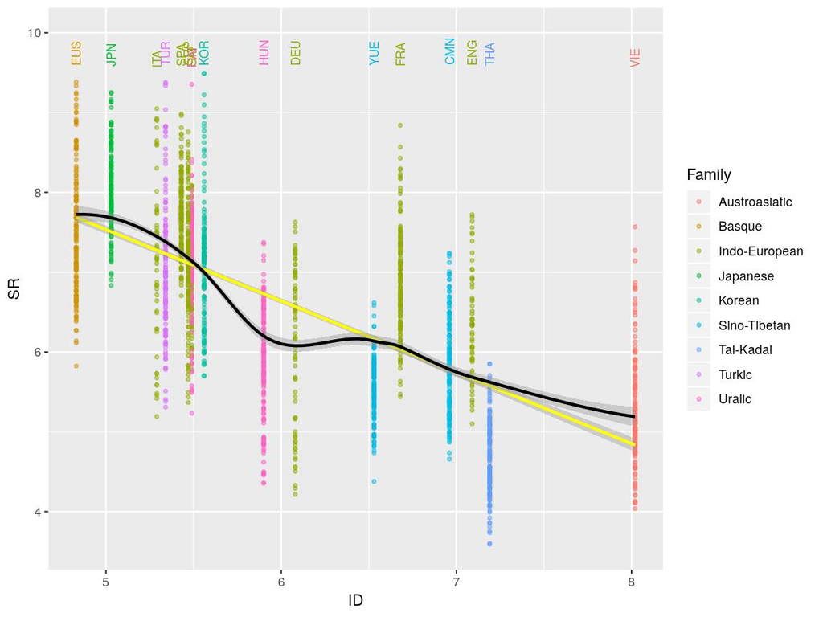

SR vs ID

```
    Pearson's product-moment correlation

data:  info.rate.data$SR and info.rate.data$ID
t = -45.329, df = 2286, p-value < 2.2e-16
alternative hypothesis: true correlation is not equal to 0
95 percent confidence interval:
 -0.7090031 -0.6658066
sample estimates:
       cor
-0.6880138
```

```
    Spearman's rank correlation rho

data:  info.rate.data$SR and info.rate.data$ID
S = 3393600000, p-value < 2.2e-16
alternative hypothesis: true rho is not equal to 0
sample estimates:
       rho
-0.6999614
```

## Linear Mixed Models (LMMs)

### Linear ICCs

ICC for model `NS ~ 1 + (1 | Text) + (1 | Family/Language)+ (1 | Speaker)`.

| Level-1 factor (f) | ICC |
| --- | --- |
| Text | 0.26 |
| Family | 0.42 |
| Language | 0.19 |
| Speaker | 0.00 |

ICC for model `SR ~ 1 + (1 | Text) + (1 | Family/Language)+ (1 | Speaker)`.

| Level-1 factor (f) | ICC |
| --- | --- |
| Text | 0.01 |
| Family | 0.50 |
| Language | 0.19 |
| Speaker | 0.24 |

ICC for model `ShIR ~ 1 + (1 | Text) + (1 | Family/Language)+ (1 | Speaker)`.

| Level-1 factor (f) | ICC |
| --- | --- |
| Text | 0.01 |
| Family | 0.47 |
| Language | 0.13 |
| Speaker | 0.30 |

ICC for model `IR ~ 1 + (1 | Text) + (1 | Family/Language)+ (1 | Speaker)`.

| Level-1 factor (f) | ICC |
| --- | --- |
| Text | 0.02 |
| Family | 0.03 |
| Language | 0.32 |
| Speaker | 0.49 |

### SR

#### Comparing models

AIC and BIC for various hierarchical models of `SR` (in **bold** are the minimum values).

| model | AIC | BIC |
| --- | --- | --- |
| 1 + (1 \| Text) + (1 \| Family/Language) + (1 \| Speaker) | 2127.51 | 2161.93 |
| 1 + (1 \| Family/Language) + (1 \| Speaker) | 2397.97 | 2426.65 |
| 1 + (1 \| Text) + (1 \| Speaker) | 2257.73 | 2280.68 |
| 1 + (1 \| Text) + (1 \| Family/Language) | 4717.06 | 4745.73 |
| 1 + Sex + (1 \| Text) + (1 \| Family/Language) + (1 \| Speaker) | **2121.04** | **2161.19** |
| 1 + Sex + (1 \| Family/Language) + (1 \| Speaker) | 2391.29 | 2425.7 |
| 1 + Sex + (1 \| Text) + (1 \| Speaker) | 2258.63 | 2287.31 |
| 1 + Sex + (1 \| Text) + (1 \| Family/Language) | 4584.11 | 4618.52 |

#### Residuals and random effects

We consider here the full model `SR ~ 1 + Sex + (1|Text) + (1|Family/Language) + (1|Speaker)`.

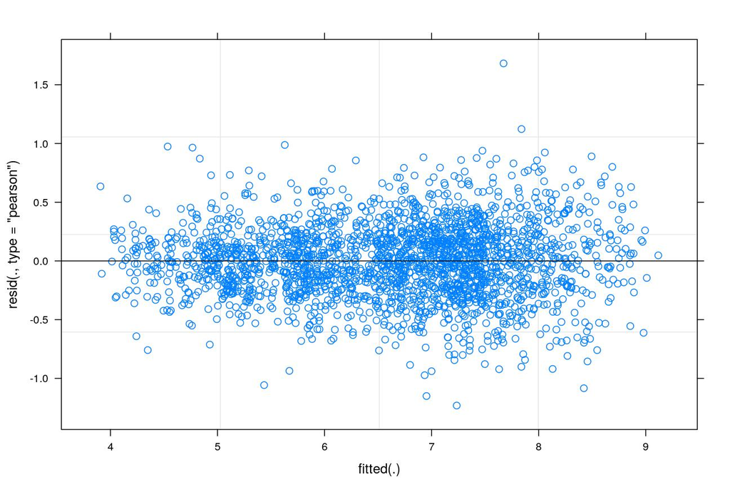

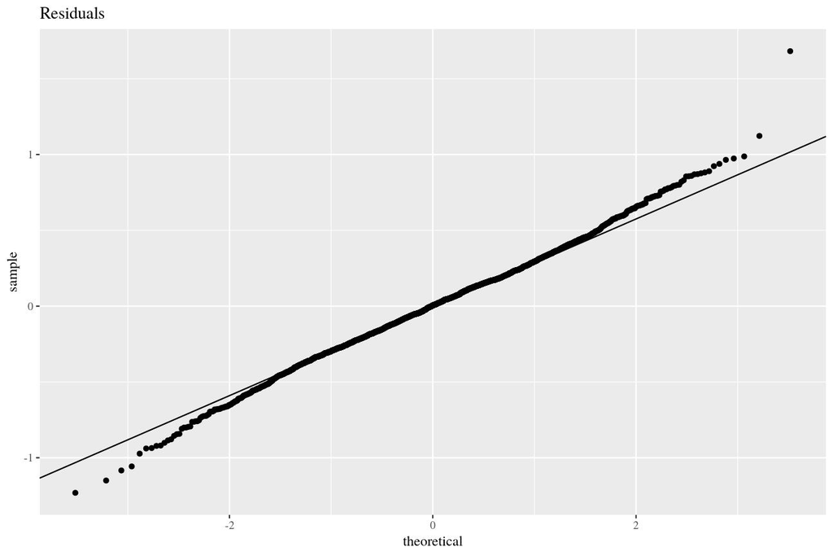

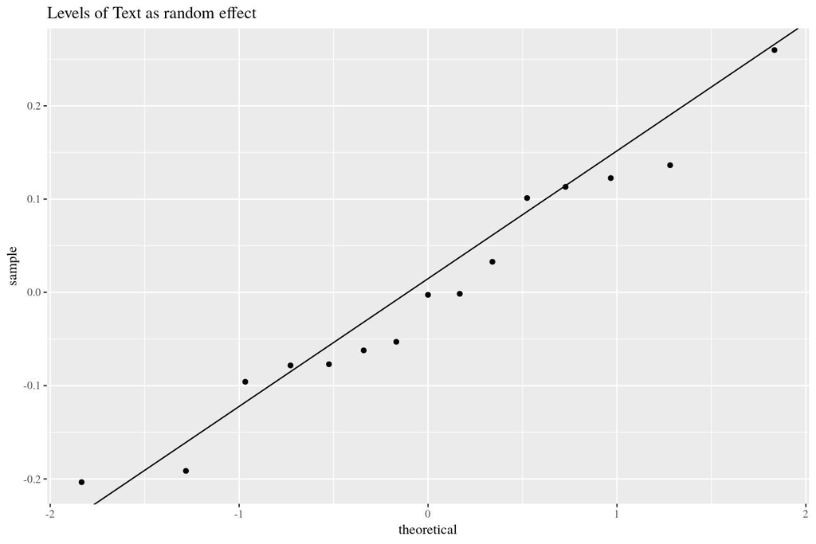

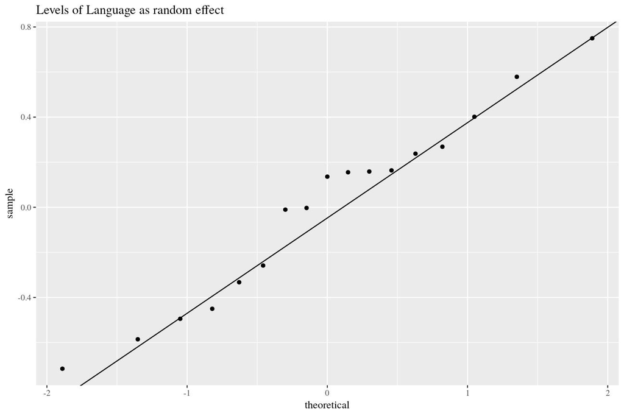

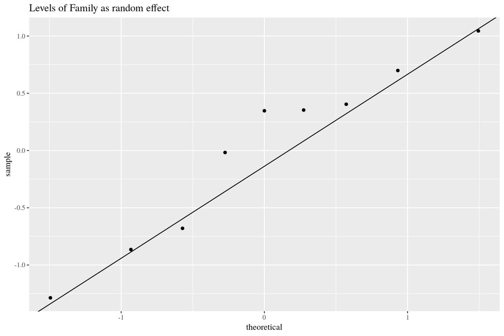

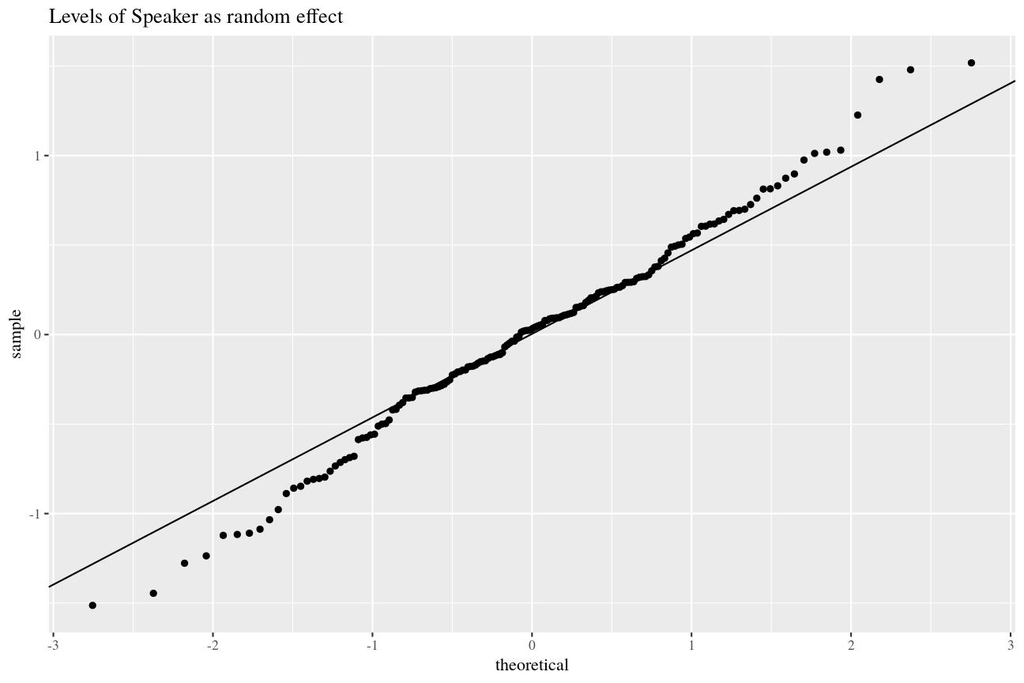

### IR

#### Comparing models

AIC and BIC for various hierarchical models of `IR` (in **bold** are the minimum values).

| model | AIC | BIC |
| --- | --- | --- |
| 1 + (1 \| Text) + (1 \| Family/Language) + (1 \| Speaker) | 10257.84 | 10292.25 |
| 1 + (1 \| Family/Language) + (1 \| Speaker) | 10524.5 | 10553.18 |
| 1 + (1 \| Text) + (1 \| Speaker) | 10305.76 | 10328.71 |
| 1 + (1 \| Text) + (1 \| Family/Language) | 12888.49 | 12917.17 |
| 1 + Sex + (1 \| Text) + (1 \| Family/Language) + (1 \| Speaker) | **10247.34** | **10287.49** |
| 1 + Sex + (1 \| Family/Language) + (1 \| Speaker) | 10513.79 | 10548.21 |
| 1 + Sex + (1 \| Text) + (1 \| Speaker) | 10300.05 | 10328.72 |
| 1 + Sex + (1 \| Text) + (1 \| Family/Language) | 12747.04 | 12781.45 |

#### Residuals and random effects

We consider here the full model `IR ~ 1 + Sex + (1|Text) + (1|Family/Language) + (1|Speaker)`.

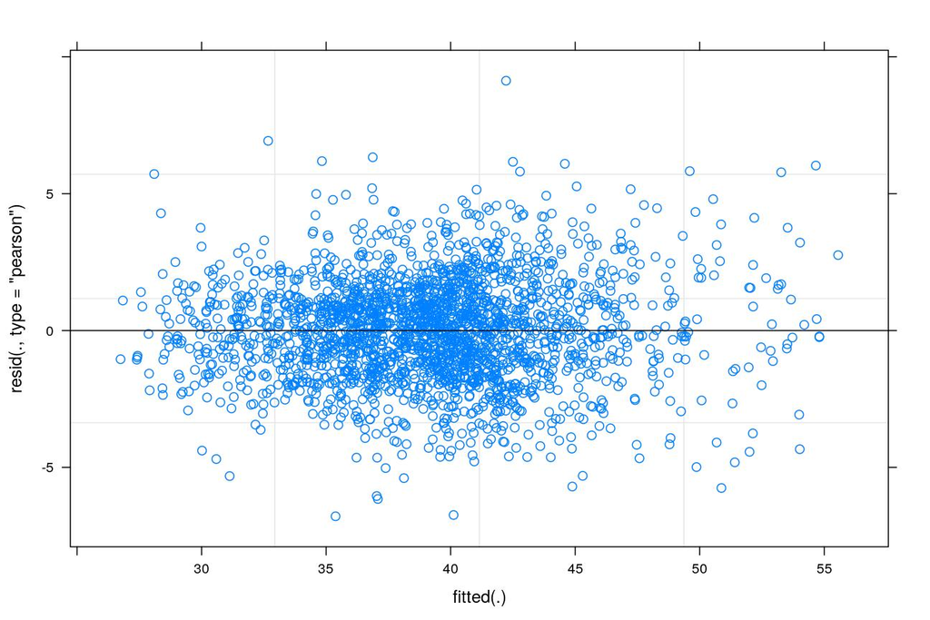

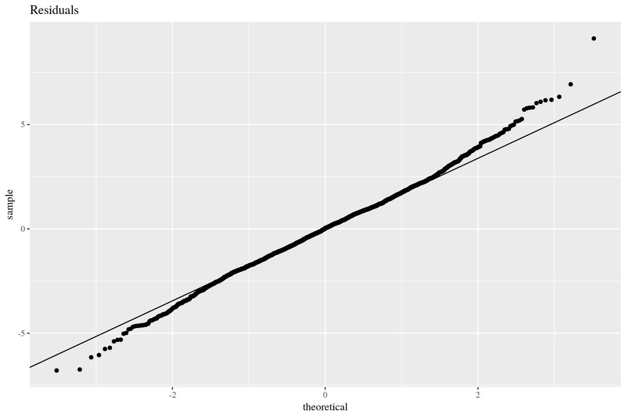

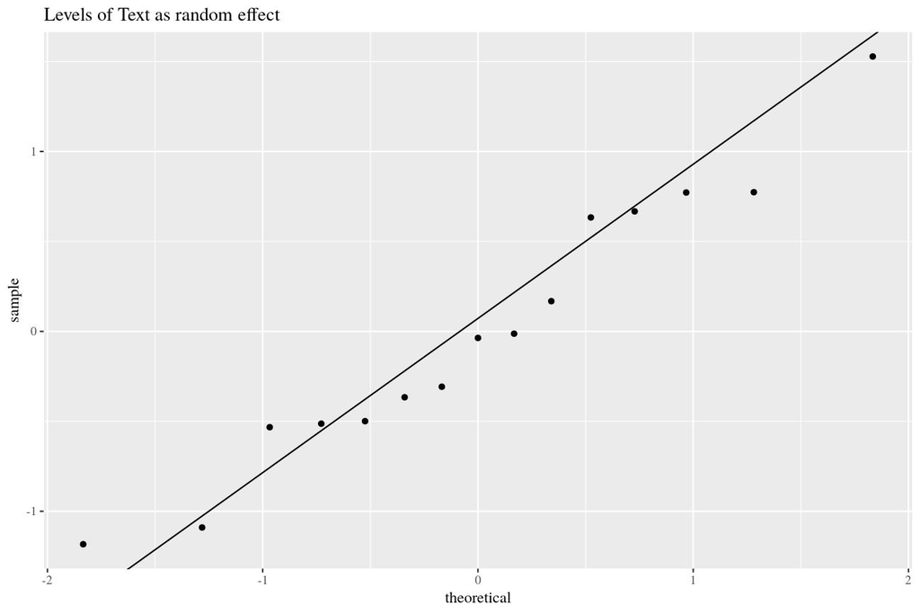

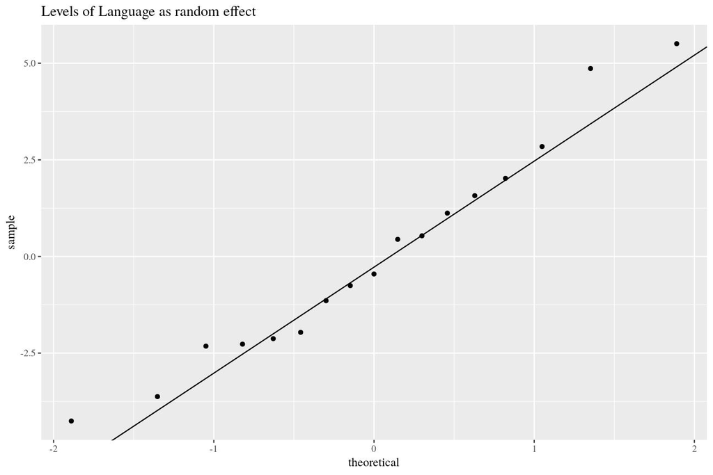

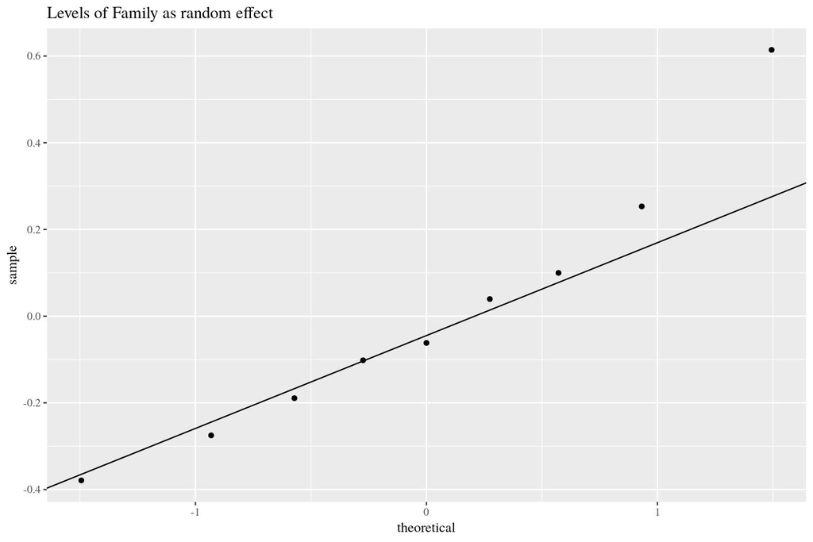

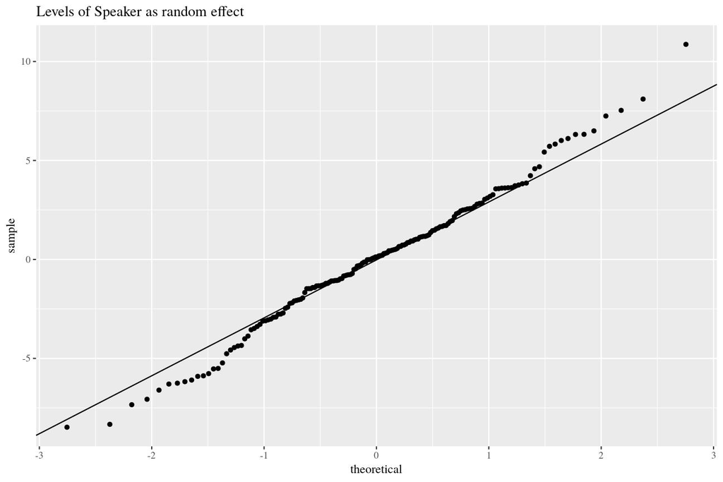